# Simulated Observational Two-Stage DTR Case Study

IBC 2026 Short Course - Module 2 code demonstration

IBC 2026 Short Course

July 12, 2026

# 1 Setup

```r
library(DynTxRegime)
library(rpart)
```

# 2 The clinical scenario and questions of interest

Imagine a chronic condition managed over **two clinic visits**. At each visit the clinician chooses between two options:

- **`Control`** — standard care (lower intensity).
- **`Intensive`** — augmented therapy (higher intensity, more burden and cost).

We observe each patient’s baseline profile, the treatment actually given at visit 1, an **interim risk marker** measured before visit 2, the visit-2 treatment, and a final outcome `Y` (a functional / quality-of-life score, coded so **larger is better**).

| Symbol | Variable | Meaning |
| --- | --- | --- |
| $X_1$ | `severity` | baseline disease severity (larger = worse) |
|  | `age_z` | standardized age |
|  | `comorb` | comorbidity present (0/1) |
|  | `adherence` | adherence (larger = better) |
| $A_1$ | `A1` | visit-1 treatment (`Control` / `Intensive`) |
| $X_2$ | `risk2` | **interim** risk/severity marker after visit 1 (larger = worse) |
| $A_2$ | `A2` | visit-2 treatment (`Control` / `Intensive`) |
| $Y$ | `Y` | final health outcome (larger = better) |

**This is observational data, not a randomized trial.** Sicker, higher-risk patients are preferentially given `Intensive` care at *both* visits, so the treated and untreated groups are not comparable — and `risk2` is itself pushed down by intensive visit-1 care. The causal structure is

$$X_1 \;\to\; A_1 \;\to\;
X_2\,(\texttt{risk2}) \;\to\; A_2 \;\to\; Y,$$

with $X_1$ confounding $A_1$ and $(X_1, A_1, X_2)$ confounding $A_2$. Because `risk2` is **both** a consequence of $A_1$ and a confounder of $A_2$, it is a *time-dependent confounder* — the feature that makes the problem genuinely sequential.

**Questions of interest.**

1. **Is the naive analysis biased?** How badly does confounding distort a simple treated-vs-untreated comparison?
2. **Can we recover the treatment mechanism?** Fit the propensity, check it against the known truth, and ask whether overlap/positivity is adequate — and how fragile multi-stage weights become.
3. **What is the optimal two-stage rule — who gets `Intensive`, and when?** Estimate it two ways: Q-learning (indirect) and AIPW/classification (direct).
4. **How much does individualizing help,** relative to “always control”, “always intensive”, and the unattainable oracle?
5. **How trustworthy are the estimates** — are in-sample values optimistic, and which methods survive a misspecified model?

# 3 Data-generating process

The observed trajectory is $O=(X_1,A_1,X_2,A_2,Y)$. Because we build the world, we know every ingredient a real analysis must *estimate* — the propensity, the outcome model, and the truly optimal rule. The generative model has three pieces.

**1. Treatment assignment (the propensity).** At each visit the probability of `Intensive` rises with disease burden — higher `severity`, `comorb`, and (at visit 2) higher `risk2` — and falls with `adherence`. This is *confounding by indication*: the sickest patients are steered toward the aggressive option.

**2. The interim marker.** `risk2` rises with baseline severity but is **lowered by intensive visit-1 treatment**, so $A_1$ has a downstream effect that surfaces only through `risk2`.

**3. The outcome and its treatment effects.** The outcome decomposes as
$$Y \;=\;
\underbrace{\mu(X_1,X_2)}_{\text{prognosis}} \;+\;
\underbrace{C_1(X_1)}_{\text{blip}_1}\,A_1 \;+\;
\underbrace{C_2(H_2)}_{\text{blip}_2}\,A_2 \;+\; \varepsilon,$$
where each **blip** $C_k$ is the *conditional benefit of `Intensive`* at that stage — exactly the contrast an optimal rule keys on. The blips vary across patients (they depend on severity, comorbidity, and interim risk) - hence the need for personalization.

> $C_k(h_k)$ is the structural-nested-mean-model blip that A-learning and g-estimation target directly, and that Q-learning recovers as its `moCont` contrast. The optimal rule is $d_k^{\mathrm{opt}}(h_k)=\mathbb{I}\{C_k(h_k)>0\}$.

> `risk2` is the crux of the multi-stage observational problem: it is **affected by the stage-1 action** (intensive care lowers it), it then **confounds the stage-2 decision** (higher risk $\to$ more intensive), and it **drives the outcome**. A variable that is at once a *mediator* of past treatment and a *confounder* of future treatment cannot be handled by naive regression adjustment — it is exactly why sequential methods (backward induction, g-estimation, AIPW) exist.

```r
expit <- function(x) 1 / (1 + exp(-x))

tx_levels <- c("Control", "Intensive")
sigma_x2 <- 0.75
sigma_y  <- 1.50

make_baseline <- function(n) {
  severity  <- rnorm(n)
  age_z     <- rnorm(n)
  adherence <- rnorm(n)
  comorb    <- rbinom(n, size = 1, prob = expit(-0.25 + 0.70 * severity + 0.25 * age_z))

  data.frame(
    id = seq_len(n),
    severity = severity,
    age_z = age_z,
    comorb = comorb,
    adherence = adherence
  )
}

p1_fun <- function(dat) {
  with(dat, expit(-0.25 + 1.00 * severity + 0.65 * comorb -
                    0.45 * adherence + 0.20 * age_z))
}

mu_risk2 <- function(dat, a1_num) {
  with(dat, 0.55 * severity + 0.45 * comorb - 0.35 * adherence +
         0.25 * age_z - (0.55 + 0.25 * severity) * a1_num)
}

p2_fun <- function(dat) {
  with(dat, expit(-0.30 + 1.15 * risk2 + 0.35 * severity +
                    0.50 * comorb - 0.35 * a1_num - 0.20 * adherence))
}

blip1_fun <- function(dat) {
  with(dat, -0.20 + 0.90 * severity + 0.50 * comorb - 0.40 * adherence)
}

blip2_fun <- function(dat) {
  with(dat, -0.35 + 1.10 * risk2 + 0.35 * severity +
         0.45 * comorb - 0.25 * a1_num)
}

mean_y_fun <- function(dat) {
  with(dat, 24 - 1.80 * severity - 1.20 * risk2 - 1.00 * comorb +
         0.30 * adherence - 0.20 * age_z +
         blip1_fun(dat) * a1_num + blip2_fun(dat) * a2_num)
}

expected_positive_normal <- function(mu, sd) {
  z <- mu / sd
  sd * dnorm(z) + mu * pnorm(z)
}

stage1_value_if <- function(dat, a1_num) {
  mu2 <- mu_risk2(dat, a1_num = a1_num)
  mean_blip2 <- with(dat, -0.35 + 1.10 * mu2 + 0.35 * severity +
                       0.45 * comorb - 0.25 * a1_num)
  sd_blip2 <- abs(1.10) * sigma_x2
  mean_base <- with(dat, 24 - 1.80 * severity - 1.20 * mu2 - 1.00 * comorb +
                      0.30 * adherence - 0.20 * age_z)

  mean_base + blip1_fun(dat) * a1_num +
    expected_positive_normal(mean_blip2, sd_blip2)
}

oracle_a1 <- function(dat) {
  as.integer(stage1_value_if(dat, 1) > stage1_value_if(dat, 0))
}

oracle_a2 <- function(dat) {
  as.integer(blip2_fun(dat) > 0)
}

tx_factor <- function(a) {
  factor(ifelse(a == 1, "Intensive", "Control"), levels = tx_levels)
}
```

```r
simulate_observational_data <- function(n, seed = NULL) {
  if (!is.null(seed)) set.seed(seed)

  dat <- make_baseline(n)

  dat$p1_true <- p1_fun(dat)
  dat$a1_num <- rbinom(n, size = 1, prob = dat$p1_true)
  dat$A1 <- tx_factor(dat$a1_num)

  dat$risk2 <- mu_risk2(dat, dat$a1_num) + rnorm(n, sd = sigma_x2)

  dat$p2_true <- p2_fun(dat)
  dat$a2_num <- rbinom(n, size = 1, prob = dat$p2_true)
  dat$A2 <- tx_factor(dat$a2_num)

  dat$blip1_true <- blip1_fun(dat)
  dat$blip2_true <- blip2_fun(dat)
  dat$d1_oracle <- tx_factor(oracle_a1(dat))
  dat$d2_oracle <- tx_factor(oracle_a2(dat))

  dat$Y_mean <- mean_y_fun(dat)
  dat$Y <- dat$Y_mean + rnorm(n, sd = sigma_y)

  dat
}

n_train <- 1500
obs <- simulate_observational_data(n_train, seed = 101)

str(obs)
```

```
## 'data.frame':    1500 obs. of  18 variables:
##  $ id        : int  1 2 3 4 5 6 7 8 9 10 ...
##  $ severity  : num  -0.326 0.552 -0.675 0.214 0.311 ...
##  $ age_z     : num  0.0447 0.5683 -0.6142 0.5675 0.1807 ...
##  $ comorb    : int  0 1 0 0 0 0 0 1 0 0 ...
##  $ adherence : num  0.274 -0.194 0.707 1.59 -0.123 ...
##  $ p1_true   : num  0.334 0.76 0.203 0.346 0.538 ...
##  $ a1_num    : int  0 1 1 1 0 1 0 0 1 0 ...
##  $ A1        : Factor w/ 2 levels "Control","Intensive": 1 2 2 2 1 2 1 1 2 1 ...
##  $ risk2     : num  -0.261 -0.462 -0.725 -1.242 -0.482 ...
##  $ p2_true   : num  0.3165 0.3895 0.1346 0.0894 0.3271 ...
##  $ a2_num    : int  1 0 0 0 0 0 0 0 1 0 ...
##  $ A2        : Factor w/ 2 levels "Control","Intensive": 2 1 1 1 1 1 1 1 2 1 ...
##  $ blip1_true: num  -0.603 0.875 -1.09 -0.643 0.129 ...
##  $ blip2_true: num  -0.752 -0.465 -1.634 -1.891 -0.772 ...
##  $ d1_oracle : Factor w/ 2 levels "Control","Intensive": 1 2 1 1 2 2 2 2 2 1 ...
##  $ d2_oracle : Factor w/ 2 levels "Control","Intensive": 1 1 1 1 1 1 1 2 2 1 ...
##  $ Y_mean    : num  24.2 23.3 25.3 24.8 23.9 ...
##  $ Y         : num  23.3 22.9 26.4 22.2 23.4 ...
```

```r
summary(obs$Y)
```

```
##    Min. 1st Qu.  Median    Mean 3rd Qu.    Max.
##   16.77   22.38   23.86   24.08   25.55   34.79
```

# 4 The oracle: the true optimal regime

Because we created the data-generating process, we can compute the **oracle** — the regime that is optimal — and use it as the benchmark no estimator should beat. It was already built above (`oracle_a1`, `oracle_a2`, stored per patient as `d1_oracle` / `d2_oracle`); this section explains why/how those functions take the form they do.

The outcome was constructed in **blip form**, so the treatment effect at each stage is an explicit function of history:
$$Y = \mu(X_1,X_2) + \text{blip}_1(X_1)\,A_1 +
\text{blip}_2(H_2)\,A_2 + \varepsilon .$$
Each blip *is* the treatment contrast, so “treat wherever the blip is positive” is optimal — but only the last stage is that simple.

**Stage 2 (the final decision).** `Y` is linear in `A2` with slope $\text{blip}_2(H_2)$, so `Intensive` helps exactly where that blip is positive:
$$d_2^{\mathrm{opt}}(H_2)=\mathbb{I}\{\text{blip}_2(H_2)>0\}\qquad(\texttt{oracle\_a2}).$$

**Stage 1 (backward induction).** Choosing `A1` also shifts `risk2` (through `mu_risk2`), and `risk2` drives both the prognosis and `blip2` — the time-dependent-confounder pathway — so the stage-1 optimum has to look ahead to how we will act at stage 2. Its value is
$$V_1(H_1,a_1)=\mathbb{E}\!\left[\
\mu + \text{blip}_1\,a_1 +
\underbrace{\max_{a_2}\text{blip}_2\,a_2}_{=\,(\text{blip}_2)_+}\
\middle|\ H_1,a_1\right],$$
where the expectation is over the still-random $\text{risk2}\sim N\!\big(\mu_{\text{risk2}}(X_1,a_1),\,\sigma_{x2}\big)$. Two facts make this **closed form**:

- $\mu$ is *linear* in `risk2`, so $\mathbb{E}[\mu]$ is just $\mu$ evaluated at its mean $\mu_{\text{risk2}}$;
- $\text{blip}_2$ is *linear* in `risk2`, so $\text{blip}_2\sim N$ and the $\mathbb{E}[(\text{blip}_2)_+]$ is the normal **expected-positive-part**, $\sigma\,\phi(\mu/\sigma)+\mu\,\Phi(\mu/\sigma)$ — exactly `expected_positive_normal`.

`stage1_value_if` assembles these three pieces, and the rule picks whichever visit-1 action has the higher look-ahead value:
$$d_1^{\mathrm{opt}}(H_1)=\mathbb{I}\{V_1(H_1,1)>V_1(H_1,0)\}\qquad(\texttt{oracle\_a1}).$$

How often does the oracle send patients to `Intensive` at each visit?

```r
rbind(stage1 = table(obs$d1_oracle),
      stage2 = table(obs$d2_oracle))
```

```
##        Control Intensive
## stage1     765       735
## stage2     933       567
```

Downstream we score every learned rule against `d1_oracle` / `d2_oracle` (rule agreement) and run `policy_oracle` through the DGP to get the oracle **value** — the ceiling the estimators are trying to reach.

# 5 Confounding in observational data

The treatment mechanism is not randomized - sicker patients are more likely to receive `Intensive` at both visits.

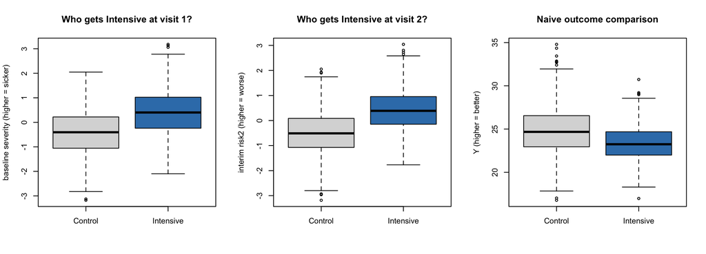

```r
par(mfrow = c(1, 3))
boxplot(severity ~ A1, data = obs, col = c("grey85", "#377EB8"),
        main = "Who gets Intensive at visit 1?", xlab = "", ylab = "baseline severity (higher = sicker)")
boxplot(risk2 ~ A2, data = obs, col = c("grey85", "#377EB8"),
        main = "Who gets Intensive at visit 2?", xlab = "", ylab = "interim risk2 (higher = worse)")
boxplot(Y ~ A1, data = obs, col = c("grey85", "#377EB8"),
        main = "Naive outcome comparison", xlab = "", ylab = "Y (higher = better)")
```

The `Intensive` arms are sicker at *both* stages, and — because of that — naively appear to do *worse*. We must condition on the history used to assign treatment!

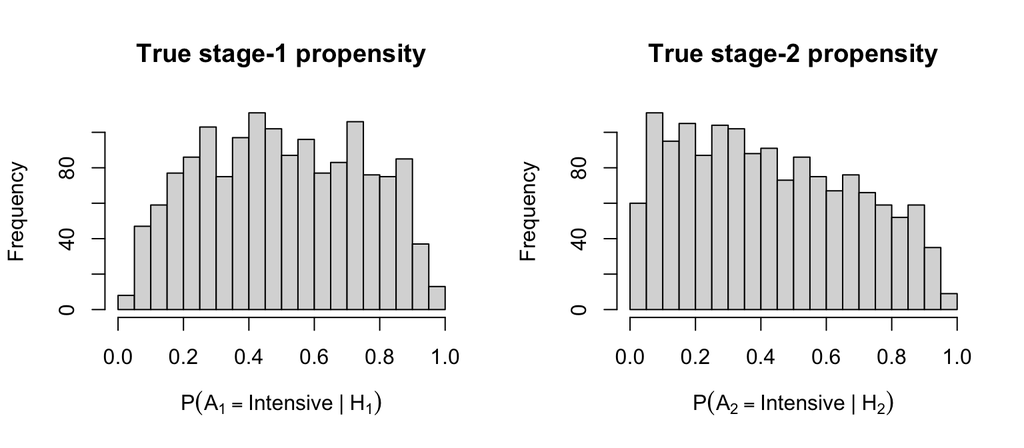

```r
par(mfrow = c(1, 2))
hist(obs$p1_true, breaks = 25, col = "grey85",
     main = "True stage-1 propensity",
     xlab = expression(P(A[1] == Intensive ~ "|" ~ H[1])))
hist(obs$p2_true, breaks = 25, col = "grey85",
     main = "True stage-2 propensity",
     xlab = expression(P(A[2] == Intensive ~ "|" ~ H[2])))
```

# 6 Estimate the propensity — and check it against the truth

The direct method (AIPW/classification) needs the propensity $\pi_k(a_k\mid h_k)=P(A_k=\text{Intensive}\mid H_k)$. We estimate a **logistic model at each stage** — stage 2 conditions on the treatment-affected interim marker:
$$\operatorname{logit}\pi_1(H_1)=\gamma_{10}+\gamma_{11}^{\top}X_1,\qquad
X_1=(\text{severity, age, comorb, adherence}),$$
$$\operatorname{logit}\pi_2(H_2)=\gamma_{20}+\gamma_{21}^{\top}H_2,\qquad
H_2=(X_1,\;A_1,\;\text{risk2}).$$
In real data you can only *estimate* these, and you must pick a specification **without** a truth to check against. To show how, we fit the correct stage-2 model **and a plausible but misspecified one** (dropping `severity`, `comorb`, and the interim `risk2`), then (i) confirm both against the known propensity, and (ii) — pretending we did *not* know it — choose between them with data-driven diagnostics.

```r
# correct AND misspecified logistic models at EACH stage
ps1_correct <- glm(a1_num ~ severity + age_z + comorb + adherence,             family = binomial, data = obs)
ps1_wrong   <- glm(a1_num ~ age_z + adherence,                                 family = binomial, data = obs)  # drops severity, comorb
ps2_correct <- glm(a2_num ~ severity + age_z + comorb + adherence + A1 + risk2, family = binomial, data = obs)
ps2_wrong   <- glm(a2_num ~ age_z + adherence + A1,                             family = binomial, data = obs)  # drops severity, comorb, risk2

obs$p1_correct <- fitted(ps1_correct);  obs$p1_wrong <- fitted(ps1_wrong)
obs$p2_correct <- fitted(ps2_correct);  obs$p2_wrong <- fitted(ps2_wrong)
obs$p1_hat <- obs$p1_correct            # the CORRECT models feed the methods downstream
obs$p2_hat <- obs$p2_correct
```

## 6.1 Check against the truth (only possible in a simulation)

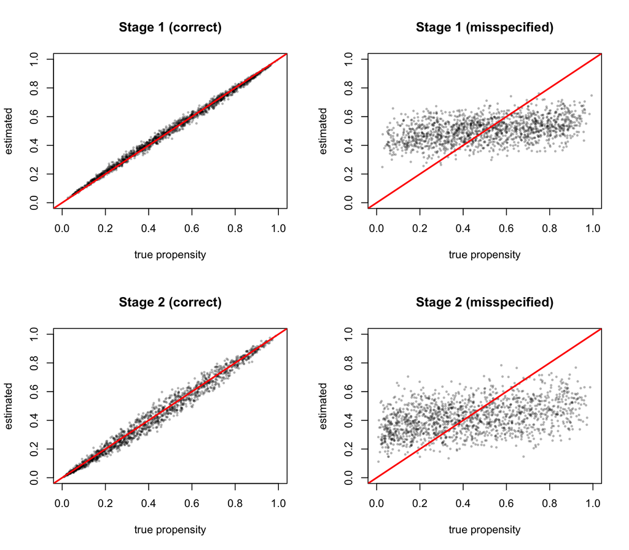

```r
calib <- function(truth, est, main) {
  plot(truth, est, pch = 16, cex = 0.5, col = rgb(0, 0, 0, 0.3),
       xlab = "true propensity", ylab = "estimated", xlim = c(0, 1), ylim = c(0, 1), main = main)
  abline(0, 1, col = "red", lwd = 2)
}
par(mfrow = c(2, 2))
calib(obs$p1_true, obs$p1_correct, "Stage 1 (correct)")
calib(obs$p1_true, obs$p1_wrong,   "Stage 1 (misspecified)")
calib(obs$p2_true, obs$p2_correct, "Stage 2 (correct)")
calib(obs$p2_true, obs$p2_wrong,   "Stage 2 (misspecified)")
```

## 6.2 Choosing the model *without* the truth

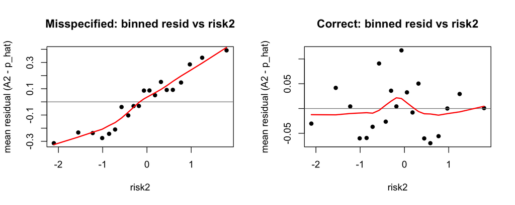

```r
aic <- c(correct = AIC(ps2_correct), misspecified = AIC(ps2_wrong))    # (1) fit: lower is better

# (2) residual check: binned residuals vs the omitted driver risk2 (analog of the Q-learning plot)
binned <- function(x, r, main, nb = 20) {
  b  <- cut(x, unique(quantile(x, seq(0, 1, length.out = nb + 1))), include.lowest = TRUE)
  xm <- tapply(x, b, mean); rm <- tapply(r, b, mean)
  plot(xm, rm, pch = 16, xlab = "risk2", ylab = "mean residual (A2 - p_hat)", main = main)
  abline(h = 0, col = "grey50"); lines(lowess(xm, rm), col = "red", lwd = 2)
}
par(mfrow = c(1, 2))
binned(obs$risk2, obs$a2_num - obs$p2_wrong,   "Misspecified: binned resid vs risk2")
binned(obs$risk2, obs$a2_num - obs$p2_correct, "Correct: binned resid vs risk2")
```

```r
round(aic, 1)
```

```
##      correct misspecified
##       1589.9       1966.3
```

# 7 Multi-stage IPW weights get fragile

Inverse-probability weighting reweights each patient by $1/\pi$ so the treated look like the whole population. In a *sequence* the weight is the **product** across stages, $1/\{\pi_1(a_1\mid h_1)\,\pi_2(a_2\mid h_2)\}$ — and a product of small numbers has a heavy right tail. A few patients on an unlikely treatment path acquire enormous weights and dominate any IPW estimate.

> Each extra stage multiplies another $1/\pi$ into the weight, so the effective sample shrinks geometrically — the motivation for stabilized weights, augmentation (AIPW), or avoiding full-product inversion altogether.

```r
# weight of each patient's OBSERVED path, using the fitted propensities
pi1_obs <- with(obs, ifelse(a1_num == 1, p1_hat, 1 - p1_hat))
pi2_obs <- with(obs, ifelse(a2_num == 1, p2_hat, 1 - p2_hat))
w1 <- 1 / pi1_obs                        # stage-1 weight only
w2 <- 1 / (pi1_obs * pi2_obs)            # cumulative two-stage weight

ess       <- function(w) sum(w)^2 / sum(w^2)                                   # Kish effective sample size
top_share <- function(w, p = 0.01) sum(sort(w, TRUE)[seq_len(ceiling(p * length(w)))]) / sum(w)

round(c(
  n             = nrow(obs),
  ESS_stage1    = ess(w1),
  ESS_two_stage = ess(w2),
  max_weight    = max(w2),
  top1pct_share = top_share(w2)          # weight share held by the heaviest 1% of patients
), 2)
```

```
##             n    ESS_stage1 ESS_two_stage    max_weight top1pct_share
##       1500.00       1099.61        588.46         65.48          0.10
```

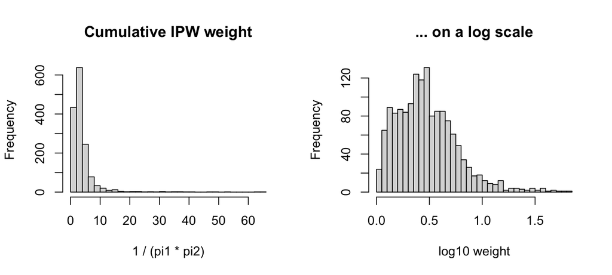

```r
par(mfrow = c(1, 2))
hist(w2,        breaks = 40, col = "grey85", main = "Cumulative IPW weight", xlab = "1 / (pi1 * pi2)")
hist(log10(w2), breaks = 40, col = "grey85", main = "... on a log scale",     xlab = "log10 weight")
```

**Interpretation.** The effective sample size drops from $n$ toward a fraction of it once the second stage folds in, the maximum weight dwarfs the average, and the heaviest 1% of patients carry an outsized share of the total. That is *why* a raw multi-stage IPW value is noisy — and why the direct method below leans on **augmentation** (AIPW) instead of inverting the whole propensity product at once.

# 8 Fit Q-learning

Q-learning models the outcome regression at each stage as a **main effect plus a treatment contrast** (the blip), and reads the rule off the contrast. **Stage 2** (solved first):
$$Q_2(H_2,a_2)=\mathbb{E}[Y\mid
H_2,A_2=a_2]=\nu_2(H_2)+a_2\,C_2(H_2),\qquad
d_2^{\mathrm{opt}}(H_2)=\mathbb{I}\{\widehat C_2(H_2)>0\},$$
$$V_2(H_2)=\max_{a_2}Q_2(H_2,a_2)=\nu_2(H_2)+\max\{0,\,C_2(H_2)\}.$$
**Stage 1** regresses that optimal *future* value on the baseline history:
$$Q_1(H_1,a_1)=\mathbb{E}[V_2\mid
H_1,A_1=a_1]=\nu_1(H_1)+a_1\,C_1(H_1),\qquad
d_1^{\mathrm{opt}}(H_1)=\mathbb{I}\{\widehat
C_1(H_1)>0\}.$$

> Solve the *last* decision first, then step back; in code, the stage-2 fit is passed as the `response` for stage 1, carrying the pseudo-outcome $V_2=\max_{a_2}Q_2$ backward. Only the **contrast** (`moCont`) terms decide the rule.

## 8.1 Choosing the stage-2 outcome model

The rule is only as good as the $Q_2$ model beneath it, so we check it first. We compare two candidate specifications with standard linear-model diagnostics. Both write the stage-2 Q-function as a main effect plus an `A2` contrast, $Q_2=\nu_2+a_2C_2$ (with $a_2=1$ for `Intensive`).

*Correct* (matches the DGP):
$$\begin{aligned}
Q_2(H_2,a_2)=\;&
\beta_0+\beta_1\,\text{sev}+\beta_2\,\text{age}+\beta_3\,\text{com}+\beta_4\,\text{adh}+\beta_5\,a_1+\beta_6\,\text{risk2}\\
&+\,a_2\big(\psi_0+\psi_1\,\text{sev}+\psi_2\,\text{com}+\psi_3\,\text{adh}+\psi_4\,a_1+\psi_5\,\text{risk2}\big).
\end{aligned}$$

*Misspecified* (`age` and `adherence` only — drops `severity`, `comorb`, `A1`, and `risk2` from both parts):
$$Q_2(H_2,a_2)=\big(\beta_0+\beta_1\,\text{age}+\beta_2\,\text{adh}\big)+a_2\big(\psi_0+\psi_1\,\text{age}+\psi_2\,\text{adh}\big).$$

(Abbreviations: sev = `severity`, age = `age_z`, com = `comorb`, adh = `adherence`; $a_1,a_2=1$ for `Intensive`.)

```r
f_correct <- Y ~ severity + age_z + comorb + adherence + A1 + risk2 +
                 A2 + A2:severity + A2:comorb + A2:adherence + A2:A1 + A2:risk2
f_wrong   <- Y ~ age_z + adherence + A2 + A2:age_z + A2:adherence

m_correct <- lm(f_correct, data = obs)
m_wrong   <- lm(f_wrong,   data = obs)

data.frame(                                     # numeric model-fit comparison
  model  = c("correct", "misspecified"),
  adj_R2 = round(c(summary(m_correct)$adj.r.squared, summary(m_wrong)$adj.r.squared), 3),
  AIC    = round(c(AIC(m_correct), AIC(m_wrong)), 1)
)
```

| model | adj_R2 | AIC |
| --- | --- | --- |
| correct | 0.632 | 5559.2 |
| misspecified | 0.158 | 6793.5 |

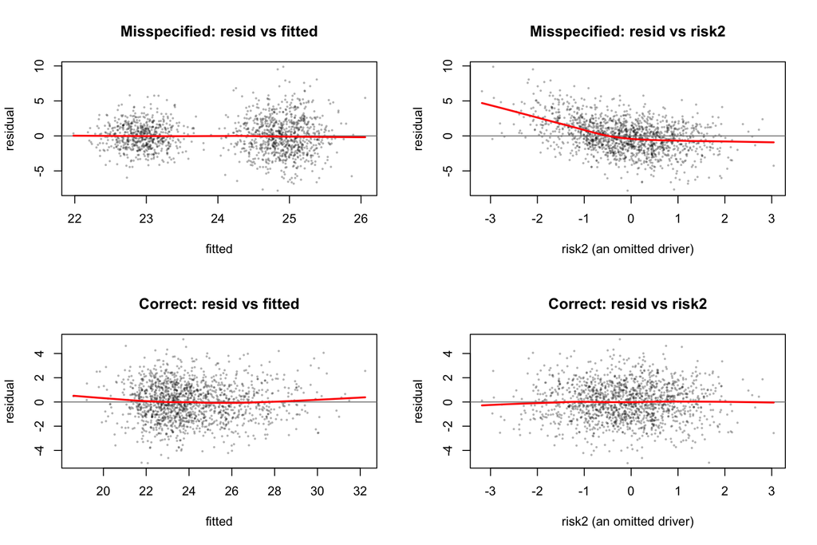

```r
# residual diagnostics: is there leftover structure the model failed to capture?
rvf <- function(m, lab) {
  plot(fitted(m), resid(m), pch = 16, cex = 0.4, col = rgb(0,0,0,0.3),
       xlab = "fitted", ylab = "residual", main = lab)
  abline(h = 0, col = "grey50"); lines(lowess(fitted(m), resid(m)), col = "red", lwd = 2)
}
rvx <- function(m, lab) {
  plot(obs$risk2, resid(m), pch = 16, cex = 0.4, col = rgb(0,0,0,0.3),
       xlab = "risk2 (an omitted driver)", ylab = "residual", main = lab)
  abline(h = 0, col = "grey50"); lines(lowess(obs$risk2, resid(m)), col = "red", lwd = 2)
}
par(mfrow = c(2, 2))
rvf(m_wrong,   "Misspecified: resid vs fitted")
rvx(m_wrong,   "Misspecified: resid vs risk2")
rvf(m_correct, "Correct: resid vs fitted")
rvx(m_correct, "Correct: resid vs risk2")
```

The misspecified model has a lower adjusted $R^2$, a much higher AIC, and a clear pattern in the residuals. The correct model’s residuals are flat against both fitted values and `risk2`. We proceed with the correct specification, which is exactly the `moMain2`/`moCont2` handed to `qLearn` next.

## 8.2 Backward fit

Stage 2 fits the **correct** $Q_2$ chosen above (`moMain2` $=\nu_2$, `moCont2` $=C_2$); its optimal value $\widehat V_2$ is then carried back as the response for stage 1.

```r
moMain2 <- buildModelObj(
  model = ~ severity + age_z + comorb + adherence + A1 + risk2,
  solver.method = "lm"
)

moCont2 <- buildModelObj(
  model = ~ severity + comorb + adherence + A1 + risk2,
  solver.method = "lm"
)

qSS <- qLearn(
  moMain = moMain2,
  moCont = moCont2,
  data = obs,
  response = obs$Y,
  txName = "A2",
  verbose = FALSE
)

coef(qSS)
```

```
## $outcome
## $outcome$Combined
##             (Intercept)                severity                   age_z
##             24.15870017             -1.47458091             -0.18896532
##                  comorb               adherence             A1Intensive
##             -0.69628367              0.08168711             -0.27345643
##                   risk2             A2Intensive    severity:A2Intensive
##             -1.28835059             -0.48105405              0.74330764
##      comorb:A2Intensive   adherence:A2Intensive A1Intensive:A2Intensive
##              0.27930773             -0.10073150             -0.03550639
##       risk2:A2Intensive
##              1.18612543
```

Stage 1 regresses that stage-2 optimal value $\widehat V_2$ (the `qSS` object) on the baseline history, again as a main effect plus an `A1` contrast, $Q_1=\nu_1+a_1C_1$:
$$\begin{aligned}
Q_1(H_1,a_1)=\;&
\alpha_0+\alpha_1\,\text{sev}+\alpha_2\,\text{age}+\alpha_3\,\text{com}+\alpha_4\,\text{adh}\\
&+\,a_1\big(\phi_0+\phi_1\,\text{sev}+\phi_2\,\text{age}+\phi_3\,\text{com}+\phi_4\,\text{adh}\big).
\end{aligned}$$

```r
moMain1 <- buildModelObj(
  model = ~ severity + age_z + comorb + adherence,
  solver.method = "lm"
)

moCont1 <- buildModelObj(
  model = ~ severity + age_z + comorb + adherence,
  solver.method = "lm"
)

qFS <- qLearn(
  moMain = moMain1,
  moCont = moCont1,
  data = obs,
  response = qSS,
  txName = "A1",
  verbose = FALSE
)

coef(qFS)
```

```
## $outcome
## $outcome$Combined
##           (Intercept)              severity                 age_z
##           24.56188516           -1.80989020           -0.44076415
##                comorb             adherence           A1Intensive
##           -0.98625135            0.35015629            0.08301076
##  severity:A1Intensive     age_z:A1Intensive    comorb:A1Intensive
##            0.44501488            0.13967276            0.08784016
## adherence:A1Intensive
##           -0.03061619
```

```r
estimator(qFS)
```

```
## [1] 24.4066
```

**Reading the fit.** The `moCont2` contrast coefficients recover the stage-2 blip: `Intensive` is favored where that contrast is positive — here, for higher `risk2` and `severity`, i.e. sicker patients. The stage-1 contrast will *not* exactly equal `blip1`, because the true stage-1 effect also carries the downstream value of lowering `risk2`; `estimator(qFS)` is the in-sample plug-in value.

# 9 Fit the direct AIPW method (classification perspective)

This method targets the **value** of a regime and searches for the best one,
$$V(d)=\mathbb{E}\!\left[Y^{*}(d)\right],\qquad
d^{\mathrm{opt}}=\operatorname*{argmax}_{d}V(d).$$

**Step 1 — the AIPW (doubly robust) value.** For a *fixed* rule $d$, estimate its value by augmented inverse-probability weighting, which uses **both** the propensity $\pi$ and an outcome regression $\widehat Q(X,a)=\mathbb{E}[Y\mid X,A=a]$:
$$\widehat
V_{\mathrm{AIPW}}(d)=\frac1n\sum_i\left[\frac{C_{d,i}\,Y_i}{\pi_{d,i}}-\frac{C_{d,i}-\pi_{d,i}}{\pi_{d,i}}\,\widehat
Q\!\big(X_i,d(X_i)\big)\right],\qquad C_{d,i}=\mathbb{I}\{A_i=d(X_i)\},$$
with $\pi_{d,i}=\widehat P\{A_i=d(X_i)\mid X_i\}$. It is **doubly robust** — consistent if *either* $\pi$ or $\widehat Q$ is correct.

**Step 2 — a doubly robust contrast per patient.** The same two ingredients give each patient an AIPW estimate of their individual benefit of `Intensive`:
$$\widehat C_i=\underbrace{\widehat Q(X_i,\text{Int})-\widehat
Q(X_i,\text{Ctrl})}_{\text{outcome-model
contrast}}\;+\;\underbrace{\frac{A_i-\widehat\pi(X_i)}{\widehat\pi(X_i)\{1-\widehat\pi(X_i)\}}\big\{Y_i-\widehat
Q(X_i,A_i)\big\}}_{\text{propensity-weighted residual}}.$$
If $\widehat Q$ is right the residual term vanishes in expectation; if $\widehat\pi$ is right the residual corrects $\widehat Q$ — doubly robust either way.

**Step 3 — recast as weighted classification.** Zhang et al. (2012) show maximizing $\widehat V_{\mathrm{AIPW}}(d)$ is *equivalent* to a weighted classification: give each patient the **label** $\operatorname{sign}\widehat C_i$ (the treatment that looks better) and the **weight** $|\widehat C_i|$ (how much it matters), then solve
$$\widehat d=\operatorname*{argmin}_{d}\sum_i |\widehat
C_i|\;\mathbb{I}\{d(X_i)\neq\operatorname{sign}\widehat C_i\}.$$

**Where the tree comes in.** That last line is an *ordinary weighted classification*, so it is handed to a classifier. `DynTxRegime`’s `optimalClass()` does exactly this: the **propensity** `moPropen` and **outcome** `moMain`/`moCont` models build $\widehat C_i$ (Steps 1–2), and the **classifier** `moClass` is trained on $\{X_i,\ \operatorname{sign}\widehat C_i,\ |\widehat C_i|\}$ and *becomes* the rule (Step 3). We use a **decision tree** (`rpart`, set in `mk_class()` below), so the boundary is a staircase of axis-aligned splits (see the rule map); a logistic/SVM classifier would give a different-shaped boundary. **The double robustness lives in the AIPW labels and weights — not in the tree.**

So “**AIPW**” here is shorthand for this whole *AIPW-weighted classification* procedure (Zhang et al. 2012), not the bare value estimator. For the two-stage problem it is applied **backward**, with $Y$ replaced at each stage by the estimated optimal future value. It needs a propensity model at **each** stage; the specifications below match the mechanism that generated the data.

Following the `DynTxRegime` package, the fit is defined by four model objects:

- **`moPropen`** — model and fitting method for the **propensity for treatment** $\pi_k(a_k\mid H_k)$ (here a logistic `glm`).
- **`moMain`** — the **main-effects** component of the outcome regression, $\nu_k(H_k)$.
- **`moCont`** — the **contrasts** component of the outcome regression, $C_k(H_k)$.
- **`moClass`** — the **classifier** trained on the weighted labels (a decision tree here).

Together `moMain` + `moCont` are the outcome model $Q_k=\nu_k+a_kC_k$ that supplies the AIPW **augmentation**. *“NULL is acceptable input if IPW is desired”* — i.e. **omit `moMain`/`moCont`** and `optimalClass` reduces to plain **IPW**; **add them** and the contrast weights become **AIPW** (doubly robust).

```r
# propensity models (moPropen), one per stage
moProp1 <- buildModelObj(model = ~ severity + age_z + comorb + adherence,
                         solver.method = "glm", solver.args = list(family = "binomial"),
                         predict.method = "predict.glm", predict.args = list(type = "response"))
moProp2 <- buildModelObj(model = ~ severity + age_z + comorb + adherence + A1 + risk2,
                         solver.method = "glm", solver.args = list(family = "binomial"),
                         predict.method = "predict.glm", predict.args = list(type = "response"))

# classifier (moClass): the decision tree that fits the rule to the weighted labels
mk_class <- function(f) buildModelObj(model = f, solver.method = "rpart",
                                      solver.args = list(method = "class", control = rpart.control(cp = 0.01)),
                                      predict.args = list(type = "class"))
moClass2 <- mk_class(~ severity + comorb + adherence + A1 + risk2)
moClass1 <- mk_class(~ severity + age_z + comorb + adherence)
```

The two calls below are *identical* except that the AIPW version adds `moMain` + `moCont`. Afterward we use the package’s own extractors to *confirm* the difference: `outcome()` shows the AIPW fit carries an outcome-regression (the augmentation) while the IPW fit does not, and `classif()` returns the fitted decision tree, which we draw below.

```r
## IPW  ---  moPropen + moClass only, NO outcome model  (cf. fitSS_IPW, manual p.33)
ipwSS <- optimalClass(moPropen = moProp2, moClass = moClass2,          # <- no moMain / moCont
                      data = obs, response = obs$Y, txName = "A2", verbose = FALSE)
ipwFS <- optimalClass(moPropen = moProp1, moClass = moClass1,          # <- no moMain / moCont
                      data = obs, response = ipwSS, txName = "A1", verbose = FALSE)
```

```r
## AIPW ---  the SAME call, PLUS the outcome models  (cf. fitSS_AIPW, manual p.33)
ocSS <- optimalClass(moPropen = moProp2,
                     moMain = moMain2, moCont = moCont2,               # <- ADD outcome model => AIPW
                     moClass = moClass2,
                     data = obs, response = obs$Y, txName = "A2", verbose = FALSE)
ocFS <- optimalClass(moPropen = moProp1,
                     moMain = moMain1, moCont = moCont1,               # <- ADD outcome model => AIPW
                     moClass = moClass1,
                     data = obs, response = ocSS, txName = "A1", verbose = FALSE)
```

```r
# package fingerprint of IPW vs AIPW: does the fit carry an OUTCOME regression?
outcome(ipwSS)     # IPW  -> no augmentation model
```

```
## [1] NA
```

```r
outcome(ocSS)      # AIPW -> the outcome regression used to augment the weights
```

```
## $Combined
##
## Call:
## lm(formula = YinternalY ~ severity + age_z + comorb + adherence +
##     A1 + risk2 + A2 + severity:A2 + comorb:A2 + adherence:A2 +
##     A1:A2 + risk2:A2, data = data)
##
## Coefficients:
##             (Intercept)                 severity                    age_z
##                24.15870                 -1.47458                 -0.18897
##                  comorb                adherence              A1Intensive
##                -0.69628                  0.08169                 -0.27346
##                   risk2              A2Intensive     severity:A2Intensive
##                -1.28835                 -0.48105                  0.74331
##      comorb:A2Intensive    adherence:A2Intensive  A1Intensive:A2Intensive
##                 0.27931                 -0.10073                 -0.03551
##       risk2:A2Intensive
##                 1.18613
```

The fitted rule *is* a decision tree — `classif()` returns it, so we can draw it.

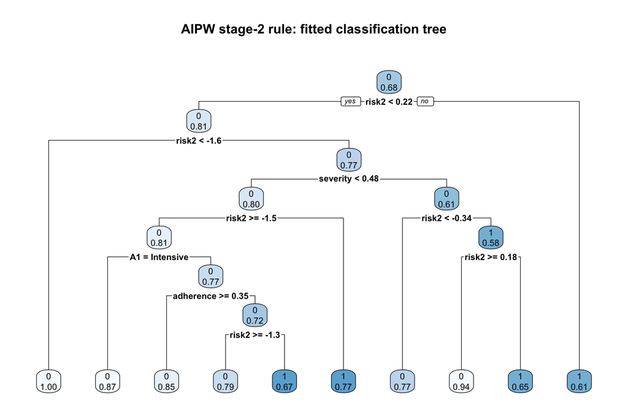

```r
oc_tree <- classif(ocSS)          # classif() returns the fitted rpart tree
if (requireNamespace("rpart.plot", quietly = TRUE)) {
  rpart.plot::rpart.plot(oc_tree, type = 2, extra = 8, box.palette = "Blues",
                         main = "AIPW stage-2 rule: fitted classification tree")
} else {
  plot(oc_tree, uniform = TRUE, margin = 0.10,
       main = "AIPW stage-2 rule: fitted classification tree")   # base-R fallback
  text(oc_tree, use.n = TRUE, all = FALSE, cex = 0.7)
}
```

*(Leaves are labelled `0` = Control, `1` = Intensive with the fitted class probability; the splits on `risk2`, `severity`, `A1`, and `adherence` are the axis-aligned cuts that make the decision-region map a staircase. The tree is deep because `cp = 0.01` — raise `cp` in `mk_class()` for a shallower, more legible display.)*

```r
# everything else is shared -> the ONLY difference is the moMain/moCont augmentation
data.frame(
  fit   = c("IPW  (moPropen + moClass)", "AIPW (+ moMain + moCont)"),
  value = round(c(estimator(ipwFS), estimator(ocFS)), 2)
)
```

| fit | value |
| --- | --- |
| IPW (moPropen + moClass) | 44.64 |
| AIPW (+ moMain + moCont) | 24.73 |

```r
sum(is.na(optTx(ipwFS)$optimalTx))                                   # IPW: patients left with NO recommendation
```

```
## [1] 651
```

```r
mean(optTx(ipwFS)$optimalTx == optTx(ocFS)$optimalTx, na.rm = TRUE)  # agreement where both are defined
```

```
## [1] 0.565371
```

**Benefit of augmentation.** The two fits share the same propensity, same classifier, same data — and differ only in the two lines that add `moMain`/`moCont`. The effect is significant: the pure-**IPW** value estimate **blows up to $\approx 45$** (the true optimum is $\approx 24.5$), it leaves **651 of the 1500 patients ($\approx 43\%$) with no recommendation** (`NA`), and where it *is* defined it agrees with the AIPW rule only $\approx 57\%$ of the time. This is the inverse-probability-weighting fragility from earlier, now *inside* the estimator: a few near-0/1 propensities make the weights explode and the backward coarsening discards nearly half the sample.

Adding the outcome augmentation (**AIPW**) stabilizes the value to $\approx 24.7$ and defines the rule for **everyone** by imputing the counterfactual outcome via a model. We carry the AIPW fit (`ocSS`/`ocFS`) forward; `optTx()` reads off the recommendation — `optTx(fit)` on the training data, `optTx(fit, newdata = ...)` for new patients — which is how we build the rule map and the policy evaluations later.

# 10 Evaluate policies under the known data-generating process

Since we are working under a simulation, we can evaluate a learned policy by deploying it in the known data-generating process on a large new population.

```r
predict_intensive <- function(obj, newdata) {
  rec <- as.character(optTx(obj, newdata = newdata)$optimalTx)
  out <- as.integer(rec == "Intensive")
  out[is.na(out)] <- 0L      # default any undefined recommendation to Control (defensive)
  out
}

simulate_policy_value <- function(n, policy, seed = NULL) {
  if (!is.null(seed)) set.seed(seed)

  dat <- make_baseline(n)
  # placeholder tx / intermediate columns so optTx(newdata=) always has the columns it expects
  dat$A1 <- factor("Control", levels = tx_levels)
  dat$A2 <- factor("Control", levels = tx_levels)
  dat$risk2 <- 0

  dat$a1_num <- policy$d1(dat)                     # stage-1 rule: baseline history only
  dat$A1 <- tx_factor(dat$a1_num)

  dat$risk2 <- mu_risk2(dat, dat$a1_num) + rnorm(n, sd = sigma_x2)

  dat$a2_num <- policy$d2(dat)                     # stage-2 rule: (baseline, A1, risk2)
  dat$A2 <- tx_factor(dat$a2_num)

  dat$Y_mean <- mean_y_fun(dat)
  dat$Y <- dat$Y_mean + rnorm(n, sd = sigma_y)

  mean(dat$Y)
}

policy_control   <- list(d1 = function(dat) rep(0L, nrow(dat)),  d2 = function(dat) rep(0L, nrow(dat)))
policy_intensive <- list(d1 = function(dat) rep(1L, nrow(dat)),  d2 = function(dat) rep(1L, nrow(dat)))
policy_oracle    <- list(d1 = function(dat) oracle_a1(dat),      d2 = function(dat) oracle_a2(dat))
policy_q         <- list(d1 = function(dat) predict_intensive(qFS, dat),   d2 = function(dat) predict_intensive(qSS, dat))
policy_oc        <- list(d1 = function(dat) predict_intensive(ocFS, dat),  d2 = function(dat) predict_intensive(ocSS, dat))
```

```r
n_eval      <- 50000
seed_common <- 2026

policy_values <- data.frame(
  policy = c(
    "Observed treatment pattern",
    "Always control",
    "Always intensive",
    "Oracle policy",
    "Q-learning policy",
    "AIPW policy"
  ),
  value = c(
    mean(obs$Y),
    simulate_policy_value(n_eval, policy_control,   seed = seed_common),
    simulate_policy_value(n_eval, policy_intensive, seed = seed_common),
    simulate_policy_value(n_eval, policy_oracle,    seed = seed_common),
    simulate_policy_value(n_eval, policy_q,         seed = seed_common),
    simulate_policy_value(n_eval, policy_oc,        seed = seed_common)
  )
)

policy_values$value <- round(policy_values$value, 2)
policy_values
```

| policy | value |
| --- | --- |
| Observed treatment pattern | 24.08 |
| Always control | 23.32 |
| Always intensive | 23.22 |
| Oracle policy | 24.52 |
| Q-learning policy | 24.47 |
| AIPW policy | 24.29 |

```r
# in-sample estimator() (what each method reports) vs the rule's TRUE value under the DGP
optimism <- data.frame(
  method     = c("Q-learning", "AIPW"),
  in_sample  = round(c(estimator(qFS), estimator(ocFS)), 2),
  true_value = policy_values$value[match(
    c("Q-learning policy", "AIPW policy"), policy_values$policy)]
)
optimism$optimism_gap <- round(optimism$in_sample - optimism$true_value, 2)
optimism
```

| method | in_sample | true_value | optimism_gap |
| --- | --- | --- | --- |
| Q-learning | 24.41 | 24.47 | -0.06 |
| AIPW | 24.73 | 24.29 | 0.44 |

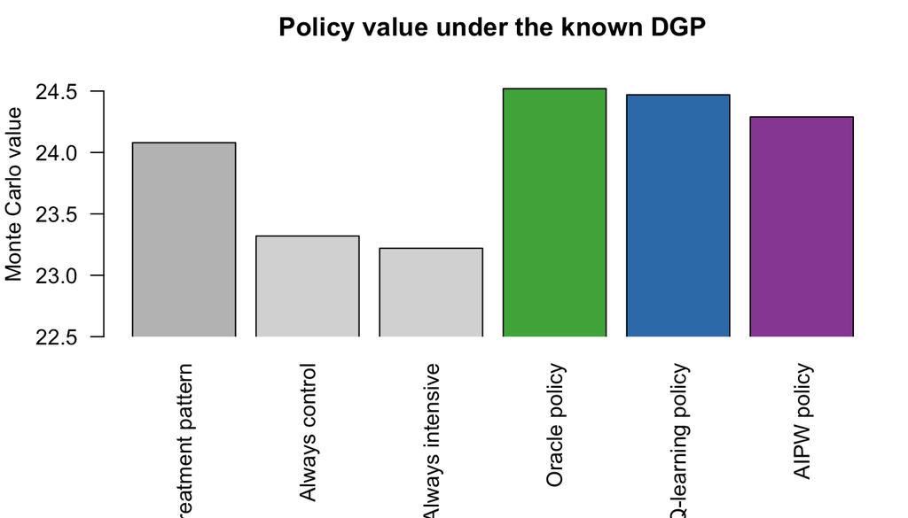

```r
op <- par(mar = c(7, 4, 2, 1))
ylo <- floor(min(policy_values$value) * 2) / 2 - 0.5     # zoom so small differences are legible
barplot(
  policy_values$value,
  names.arg = policy_values$policy,
  las = 2,
  col = c("grey75", "grey85", "grey85", "#4DAF4A", "#377EB8", "#984EA3"),
  ylab = "Monte Carlo value",
  ylim = c(ylo, max(policy_values$value) + 0.3), xpd = FALSE,
  main = "Policy value under the known DGP"
)
```

```r
par(op)
```

# 11 Double robustness: break one model at a time

Correctly specified nuisances (everything above) are the best case. AIPW is *doubly robust* — consistent if *either* the propensity or the outcome model is right. Q-learning has no propensity, so a wrong outcome model sinks it. We refit under each scenario and read off the **true** policy value (same population, so gaps are comparable).

> **Lecture link (double robustness).** AIPW gives you two chances; the outcome-only method gives you one.

```r
# deliberately WRONG nuisance models (omit the true drivers severity/comorb/risk2)
moMainW <- buildModelObj(model = ~ age_z + adherence, solver.method = "lm")
moContW <- buildModelObj(model = ~ age_z + adherence, solver.method = "lm")
moPropW <- buildModelObj(model = ~ 1, solver.method = "glm",
                         solver.args = list(family = "binomial"),
                         predict.method = "predict.glm", predict.args = list(type = "response"))

# helpers: refit a two-stage rule and return its policy (d1, d2)
fit_ql <- function(moM1, moC1, moM2, moC2) {
  ss <- qLearn(moMain = moM2, moCont = moC2, data = obs, response = obs$Y, txName = "A2", verbose = FALSE)
  fs <- qLearn(moMain = moM1, moCont = moC1, data = obs, response = ss,   txName = "A1", verbose = FALSE)
  list(d1 = function(d) predict_intensive(fs, d), d2 = function(d) predict_intensive(ss, d))
}
fit_oc <- function(moP1, moP2, moM1, moC1, moM2, moC2) {
  cls1 <- mk_class(~ severity + age_z + comorb + adherence)          # rule class stays correct
  cls2 <- mk_class(~ severity + comorb + adherence + A1 + risk2)
  ss <- optimalClass(moPropen = moP2, moMain = moM2, moCont = moC2, moClass = cls2,
                     data = obs, response = obs$Y, txName = "A2", verbose = FALSE)
  fs <- optimalClass(moPropen = moP1, moMain = moM1, moCont = moC1, moClass = cls1,
                     data = obs, response = ss, txName = "A1", verbose = FALSE)
  list(d1 = function(d) predict_intensive(fs, d), d2 = function(d) predict_intensive(ss, d))
}

seed_dr      <- 777
oracle_value <- simulate_policy_value(n_eval, policy_oracle, seed = seed_dr)   # benchmark, same population

dr <- data.frame(
  scenario = c(
    "Q-learning: correct outcome",
    "Q-learning: WRONG outcome",
    "AIPW: correct propensity + WRONG outcome",
    "AIPW: WRONG propensity (~1) + correct outcome",
    "AIPW: BOTH wrong"),
  true_value = c(
    simulate_policy_value(n_eval, fit_ql(moMain1, moCont1, moMain2, moCont2),                         seed = seed_dr),
    simulate_policy_value(n_eval, fit_ql(moMainW, moContW, moMainW, moContW),                         seed = seed_dr),
    simulate_policy_value(n_eval, fit_oc(moProp1, moProp2, moMainW, moContW, moMainW, moContW),        seed = seed_dr),
    simulate_policy_value(n_eval, fit_oc(moPropW, moPropW, moMain1, moCont1, moMain2, moCont2),        seed = seed_dr),
    simulate_policy_value(n_eval, fit_oc(moPropW, moPropW, moMainW, moContW, moMainW, moContW),        seed = seed_dr))
)
dr$true_value      <- round(dr$true_value, 2)
dr$gap_from_oracle <- round(dr$true_value - oracle_value, 2)
dr
```

| scenario | true_value | gap_from_oracle |
| --- | --- | --- |
| Q-learning: correct outcome | 24.48 | -0.05 |
| Q-learning: WRONG outcome | 23.33 | -1.20 |
| AIPW: correct propensity + WRONG outcome | 24.06 | -0.47 |
| AIPW: WRONG propensity (~1) + correct outcome | 24.47 | -0.06 |
| AIPW: BOTH wrong | 23.51 | -1.02 |

# 12 Visualize the true and learned stage-2 rule

The true stage-2 rule recommends `Intensive` when the stage-2 blip is positive. Here we compare the oracle, Q-learning, and AIPW boundaries while holding the other covariates fixed.

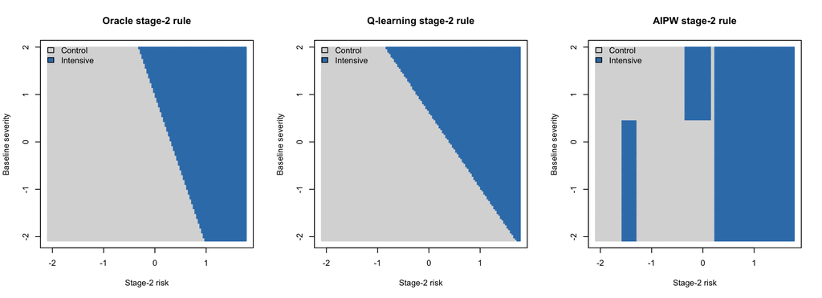

```r
grid <- expand.grid(
  risk2 = seq(quantile(obs$risk2, 0.02), quantile(obs$risk2, 0.98), length.out = 120),
  severity = seq(quantile(obs$severity, 0.02), quantile(obs$severity, 0.98), length.out = 120)
)

grid$age_z <- 0
grid$adherence <- 0
grid$comorb <- 0
grid$a1_num <- 0
grid$A1 <- factor("Control", levels = tx_levels)
grid$A2 <- factor("Control", levels = tx_levels)

grid$oracle <- tx_factor(oracle_a2(grid))
grid$qlearn <- optTx(qSS,  newdata = grid)$optimalTx
grid$oclass <- optTx(ocSS, newdata = grid)$optimalTx     # tree -> axis-aligned splits

draw_rule <- function(rec, main) {
  cols <- ifelse(rec == "Intensive", "#377EB8", "grey85")
  plot(grid$risk2, grid$severity, col = cols, pch = 15, cex = 0.7,
       xlab = "Stage-2 risk", ylab = "Baseline severity", main = main)
  legend("topleft", legend = c("Control", "Intensive"),
         fill = c("grey85", "#377EB8"), bty = "n")
}

par(mfrow = c(1, 3))
draw_rule(grid$oracle, "Oracle stage-2 rule")
draw_rule(grid$qlearn, "Q-learning stage-2 rule")
draw_rule(grid$oclass, "AIPW stage-2 rule")
```

The oracle and Q-learning boundaries are smooth half-planes (their contrast is linear). **AIPW** here uses a **decision-tree** classifier (`rpart`, set in `mk_class`), so its boundary is a staircase of axis-aligned splits.

# 13 Practical takeaways